# A brief introduction to spatial autocorrelation

## What is spatial autocorrelation?

- Spatial structures play important roles in the analysis of ecological data. Living communities are spatially structured at many spatial scales (Borcard, Gillet, and Legendre (2011)).
- The environmental elements such as climatic, physical, chemical forces control living communities. **If these factors are spatially structured, their patterns will reflect on the living communities.**
  - Example: patches in the desert where the soil is humid enough to support vegetation.

## Spatial autocorrelation

According to the geographer Waldo R. Tobler, the first law of geography is:

> Everything is related to everything else, but near things are more related than distant things.

**Spatial autocorrelation can causes problems for statistical methods that make assumptions about the independence of residuals.**

## Spatial autocorrelation

Spatial data can be positively spatially autocorrelated, negatively spatially autocorrelated, or not (or randomly) spatially autocorrelated.

**A positive spatial autocorrelation** means that similar values are close to each other.  
**A negative spatial autocorrelation** means that similar values are distant from each other.  
**A random spatial autocorrelation** means that, in general, similar values are neither close nor distant from each other.

[figure not shown]

## Moran’s index

The Moran’s index (**Moran’s I**) is widely used to measure spatial autocorrelation based on feature locations and feature values simultaneously.

$$\begin{equation}
I = \frac{n}{S_0}
\frac{\displaystyle\sum_{i=1}^n \sum_{j=1}^n w_{ij}(x_i - \bar{x})(x_j - \bar{x})}{\displaystyle\sum_{i=1}^n (x_i - \bar{x})^2}
\label{eq:morani}
\end{equation}$$
where $w_{ij}$ is the weight between observation $i$ and $j$, and $S_0$ is the sum of all $w_{ij}$’s.

## Moran’s index

Moran’s I can vary between -1 and 1 (**like a normal correlation index**).

[figure not shown]

## Moran’s I

There are two types of Moran’s I:

1. **Global Moran’s I** is a measure of the overall spatial autocorrelation.
2. **Local Moran’s I** is a measure of the local spatial autocorrelation (e.x.: locally at each station).

## A working example

We will use bird diversity data (https://bit.ly/2BLOwdd) to learn how to deal with spatial autocorrelation.

```r
df <- read_table2("data/bird.diversity.txt")  # Load tidyverse first
df <- janitor::clean_names(df)  # Clean column names

df
```

```
## # A tibble: 64 x 5
##     site bird_diversity tree_diversity lon_x lat_y
##    <dbl>          <dbl>          <dbl> <dbl> <dbl>
##  1     1           7.18           4.12 -118.  33.7
##  2     2           7.54           6.12 -117.  34.1
##  3     3           4.89           4.1  -118.  34.0
##  4     4           4.15           4.8  -118.  33.8
##  5     5           5.90           3.8  -118.  33.9
##  6     6           4.72           3.7  -118.  33.7
##  7     7           3.16           4.07 -119.  33.7
##  8     8           4.05           5    -118.  33.7
##  9     9           7.27           4.2  -118.  34.1
## 10    10           6.53           4.9  -118.  33.9
## # … with 54 more rows
```

## Tree diversity explains bird diversity

There is indeed a positive influence of tree diversity on bird diversity.

```r
ggplot(df, aes(x = tree_diversity, y = bird_diversity)) +
    geom_point(size = 3) + geom_smooth(method = "lm")
```

[figure not shown]

## Spatial distribution of the data

Spatial pattern in the data?

```r
ggplot(df, aes(x = lon_x, y = lat_y, size = bird_diversity)) +
    geom_point()
```

[figure not shown]

## Spatial distribution of the data

Relationships between geographical coordinates and bird diversity.

[figure not shown]

## Global Moran’s I

To calculate Moran’s I, we first need to generate a **matrix of inverse distance weights**. We also need to set the diagonal of the matrix to 0.

```r
sample_distances <- as.matrix(dist(cbind(df$lon_x, df$lat_y)))
sample_distances_inv <- 1 / sample_distances
diag(sample_distances_inv) <- 0

sample_distances_inv[1:6, 1:6] # Show a subset of the data
```

```
##           1         2        3        4        5        6
## 1 0.0000000 0.8993377 2.410577 1.780454 2.464641 6.926088
## 2 0.8993377 0.0000000 1.268405 1.789176 1.372575 1.032375
## 3 2.4105769 1.2684053 0.000000 2.849182 8.657011 3.184743
## 4 1.7804543 1.7891758 2.849182 0.000000 4.124330 2.396467
## 5 2.4646408 1.3725750 8.657011 4.124330 0.000000 3.609218
## 6 6.9260877 1.0323754 3.184743 2.396467 3.609218 0.000000
```

## Notes on the calculation of spatial weights

**Spatial analysis, in general, should not use lat/long when spatial weights are calculated.** This is because observations from distant locations can cause distortion. It is better to calculate distances based on spherical coordinates (projection based coordinates). This can be done using the **geosphere** package.

## Global Moran’s I

We need to install the `ape` package to calculate global Moran’s I.

```r
install.packages("ape")
library(ape)
```

## Global Moran’s I

The global Moran’s I is then calculated using the `Moran.I()` function.

```r
moran <- Moran.I(df$bird_diversity, sample_distances_inv)
moran
```

```
## $observed
## [1] 0.460358
##
## $expected
## [1] -0.01587302
##
## $sd
## [1] 0.03753738
##
## $p.value
## [1] 0
```

## Global Moran’s I

Note that under the null hypothesis that there is no spatial autocorrelation, I is calculated as:

$$I = -1/(N-1)$$
where **N** is the number of observations.

```r
-1/(nrow(df) - 1)  # Expected Moran's I
```

```
## [1] -0.01587302
```

Here, the **observed** global Moran’s I has a value of 0.46. Based on these results and the low p-value, **we can reject the null hypothesis** that there is zero spatial autocorrelation present in the bird diversity data.

## Local Moran’s I

Now that we know that there is positive spatial autocorrelation, we can verify at which spatial scales this is occurring. This can be done using the `correlog()` function from the `pgirmess` package.

```r
install.packages("pgirmess")
library(pgirmess)
```

## Local Moran’s I

```r
clog <- correlog(df[, c("lon_x", "lat_y")], z = df$bird_diversity)
plot(clog)
```

[figure not shown]

## A graphical view

[figure not shown]

## Taking care of spatial autocorrelation

## Taking care of spatial autocorrelation

There are many approaches to account for spatial autocorrelation (we will see two today).

1. Include the geographical positions, i.e. **the latitude-longitude interaction term** in the analyses.
2. Explicitly provide a spatial correlation structure that describes the nature of the autocorrelation.

## Method 1: Include the geographical positions

- First, we create the *null* model where we do not control for spatial autocorrelation.
- Then, to account for potential spatial autocorrelation we include the geographical position, i.e. the latitude-longitude interaction term in the analyses.
- Finally, we compare both models to see if spatial autocorrelation is present in the data.

## Method 1: Include the geographical positions

Create the *null* model.

```r
# Simple lm model to predict bird diversity
mod_null <- lm(bird_diversity ~ tree_diversity, data = df)
```

|  | bird diversity |  |  |
| --- | --- | --- | --- |
| Predictors | Estimates | CI | p |
| (Intercept) | 1.09 | -1.28 – 3.46 | 0.370 |
| tree diversity | 1.14 | 0.73 – 1.55 | **<0.001** |
| Observations | 64 |  |  |
| R<sup>2</sup> / adjusted R<sup>2</sup> | 0.324 / 0.313 |  |  |

Based on this model, `tree_diversity` explains 32 % of the `bird_diversity` variance.

## Method 1: Include the geographical positions

Create the model with the lat/lon **interaction**.

```r
mod_lon_lat <- lm(bird_diversity ~ tree_diversity +
    lon_x * lat_y, data = df)
```

|  | bird diversity |  |  |
| --- | --- | --- | --- |
| Predictors | Estimates | CI | p |
| (Intercept) | 10035.70 | 3010.44 – 17060.96 | **0.007** |
| tree diversity | 0.30 | -0.05 – 0.65 | 0.097 |
| lon x | 85.46 | 25.77 – 145.14 | **0.007** |
| lat y | -284.51 | -489.69 – -79.33 | **0.009** |
| lon_x:lat_y | -2.42 | -4.17 – -0.68 | **0.008** |
| Observations | 64 |  |  |
| R<sup>2</sup> / adjusted R<sup>2</sup> | 0.699 / 0.678 |  |  |

Note the p-value of **tree_diversity**.

## Comparing models

We can compare the models using Akaike’s Information Criterion (AIC).

```r
AIC(mod_null, mod_lon_lat)
```

```
##             df      AIC
## mod_null     3 265.1464
## mod_lon_lat  6 219.3481
```

The results suggest that the `mod_lon_lat` model is a better choice. This further suggests that `tree_diversity` has a limited influence on `bird_diversity`.

## Method 2: provide a spatial correlation structure

Using a variogram (also called semivariogram) is another useful way at looking for spatial autocorrelation. A variogram shows how the total variance in the data is related to the distance between observations.

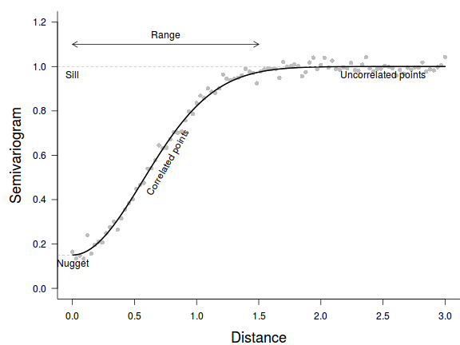

Image from http://www.flutterbys.com.au/stats/tut/tut8.4a.html

## Method 2: provide a spatial correlation structure

A variogram can take different shapes.

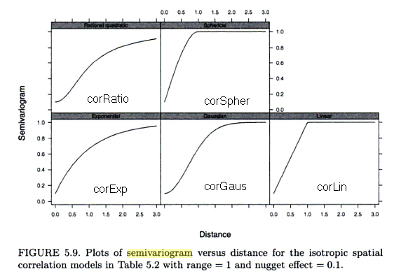

Image from Pinheiro and Bates 2004, p. 233

## Method 2: provide a spatial correlation structure

Variograms can be calculated using the `Variogram()` function from the `nlme` package. First, we need to create a Generalized Least Squares model using the `gls()`.

```r
install.packages("nlme")
library(nlme)
```

```r
# Create a null model
mod <- gls(bird_diversity ~ 1, data = df)

# Calculate the variogram on the model
semivario <-
  Variogram(mod, form = ~ lon_x + lat_y, resType = "normalized")
```

[figure not shown]

[figure not shown]

```r
plot(semivario, smooth = TRUE)
```

## Method 2: provide a spatial correlation structure

We will now test different spatial correlation structures and see which one is best for our data. This is done by setting the `correlation` argument in the `gls()` function.

```r
# Model without spatial structure
mod1 <- gls(bird_diversity ~ tree_diversity, data = df)

# Model with Gaussian structure
mod_gaus <-
  gls(
    bird_diversity ~ tree_diversity,
    correlation = corGaus(form = ~ lon_x + lat_y, nugget = TRUE),
    data = df
  )

# Model with a Linear structure
mod_lin <-
  gls(
    bird_diversity ~ tree_diversity,
    correlation = corLin(form = ~ lon_x + lat_y, nugget = TRUE),
    data = df
  )
```

```r
# Model with Exponential structure
# mod_exp <-
#   gls(
#     bird_diversity ~ tree_diversity,
#     correlation = corExp(form = ~ lon_x + lat_y, nugget = TRUE),
#     data = df
#   )

# Model with Spherical structure
mod_spher <-
  gls(
    bird_diversity ~ tree_diversity,
    correlation = corSpher(form = ~ lon_x + lat_y, nugget = TRUE),
    data = df
  )

# Model with Rational Quadratic Correlation Structureo
mod_ratio <-
  gls(
    bird_diversity ~ tree_diversity,
    correlation = corRatio(form = ~ lon_x + lat_y, nugget = TRUE),
    data = df
  )
```

## Comparing models

```r
AIC(mod1, mod_gaus, mod_lin, mod_spher, mod_ratio)
```

```
##           df      AIC
## mod1       3 267.5524
## mod_gaus   5 219.8499
## mod_lin    5 221.7109
## mod_spher  5 221.7109
## mod_ratio  5 219.8787
```

Based on the AIC, we can choose between the **Gaussian Correlation** and the **Rational Quadratic Correlation** structures.

## Variogram on the residuals

The quick inspection of the variogram calculated on the residuals confirms that the spatial structure is gone.

```r
semivario <- Variogram(mod_gaus, form = ~lon_x + lat_y,
    resType = "normalized")
plot(semivario, smooth = TRUE)
```

[figure not shown]

## Comparing models

|  | NULL model |  |  | Gaussian model |  |  |
| --- | --- | --- | --- | --- | --- | --- |
| Predictors | Estimates | CI | p | Estimates | CI | p |
| (Intercept) | 1.09 | -1.32 – 3.50 | 0.370 | 7.00 | 2.28 – 11.72 | **0.004** |
| tree diversity | 1.14 | 0.72 – 1.55 | **<0.001** | 0.13 | -0.19 – 0.45 | 0.419 |
| Observations | 64 |  |  | 64 |  |  |

After modeling the spatial structure in the data, `tree_diversity` is not significant.

## Take home messages

- At first, `tree_diversity` seemed to be an important predictor of `bird_diversity`.
- Including `lon_x` and `lat_y` interaction in a simple linear model suggested that autocorrelation was present in the data.
- Moran’s I confirmed that there was positive spatial autocorrelation in the data.
- Including a Gaussian spatial structure, based on the results of the variogram, modelled adequately the spatial autocorrelation.
- **Conclusion**: there is no relationship between `bird_diversity` and `tree_diversity` (we first identified a false positive in the data).

## References

Borcard, Daniel, Francois Gillet, and Pierre Legendre. 2011. *Numerical Ecology with R*. New York, NY: Springer New York. https://doi.org/10.1007/978-1-4419-7976-6.